# Priyanka_Chitikela_8909667_Practical_Lab3

## Practical Lab3: Vanilla CNN and Fine-Tune VGG16 - for Dogs and Cats Classification

- **Student Name** : Priyanka Chitikela
- **Student ID** : 8909667
- **Section**: 1

### **Import Libraries**

```python
from tensorflow import keras
from tensorflow.keras import layers
import pathlib
from tensorflow.keras.utils import image_dataset_from_directory
import matplotlib.pyplot as plt
```

### **Load Data into three sets**

```python
import os, shutil, pathlib

original_dir = pathlib.Path("data/kaggle_dogs_vs_cats/train")
new_base_dir = pathlib.Path("data/kaggle_dogs_vs_cats_small")

def make_subset(subset_name, start_index, end_index):
    for category in ("cat", "dog"):
        dir = new_base_dir / subset_name / category
        os.makedirs(dir)
        fnames = [f"{category}.{i}.jpg" for i in range(start_index, end_index)]
        for fname in fnames:
            shutil.copyfile(src=original_dir / fname,
                            dst=dir / fname)

make_subset("train", start_index=0, end_index=1000)
make_subset("validation", start_index=1000, end_index=1500)
make_subset("test", start_index=1500, end_index=2500)
```

```python
# This should point to the small dataset of the Kaggle Dogs vs Cats competition that was created in a previous notebook
data_folder = pathlib.Path('data/kaggle_dogs_vs_cats_small')

train_dataset = image_dataset_from_directory(
    data_folder / "train",
    image_size=(180, 180),
    batch_size=32)
validation_dataset = image_dataset_from_directory(
    data_folder / "validation",
    image_size=(180, 180),
    batch_size=32)
test_dataset = image_dataset_from_directory(
    data_folder / "test",
    image_size=(180, 180),
    batch_size=32)

# Display the class names
train_dataset.class_names
```

```
Found 2000 files belonging to 2 classes.
Found 1000 files belonging to 2 classes.
Found 2000 files belonging to 2 classes.
```

```
['cat', 'dog']
```

### **Exploratory Data Analysis (EDA)**

**Check Dataset Properties**:

```python
# Extract class names from the dataset
class_names = train_dataset.class_names

# Analyze class distribution in train, validation, and test datasets
def class_distribution(dataset):
    class_counts = {class_name: 0 for class_name in class_names}
    for _, labels in dataset:
        for label in labels:
            class_counts[class_names[label.numpy()]] += 1
    return class_counts

train_dist = class_distribution(train_dataset)
val_dist = class_distribution(validation_dataset)
test_dist = class_distribution(test_dataset)

# Display class distributions
print(f"Train class distribution: {train_dist}")
print(f"Validation class distribution: {val_dist}")
print(f"Test class distribution: {test_dist}")
```

```
Train class distribution: {'cat': 1000, 'dog': 1000}
Validation class distribution: {'cat': 500, 'dog': 500}
Test class distribution: {'cat': 1000, 'dog': 1000}
```

**Data Visualization**:

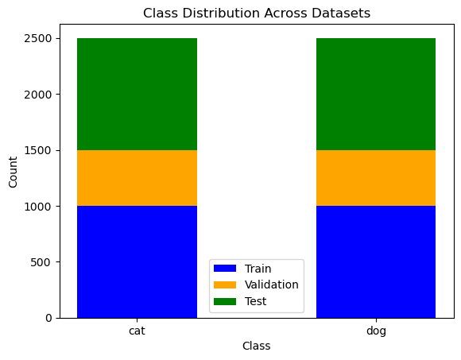

```python
# Plot class distributions as stacked bar chart
x = range(len(class_names))  # Positions for bars
bar_width = 0.5

plt.bar(x, list(train_dist.values()), bar_width, label="Train", color="blue")
plt.bar(x, list(val_dist.values()), bar_width, label="Validation", color="orange", bottom=list(train_dist.values()))
plt.bar(x, list(test_dist.values()), bar_width, label="Test", color="green",
        bottom=[train_dist[class_name] + val_dist[class_name] for class_name in class_names])

# Add labels and legend
plt.xlabel("Class")
plt.ylabel("Count")
plt.title("Class Distribution Across Datasets")
plt.xticks(x, class_names)  # Set class names as x-axis labels
plt.legend()
plt.show()
```

**Samples Visualization**:

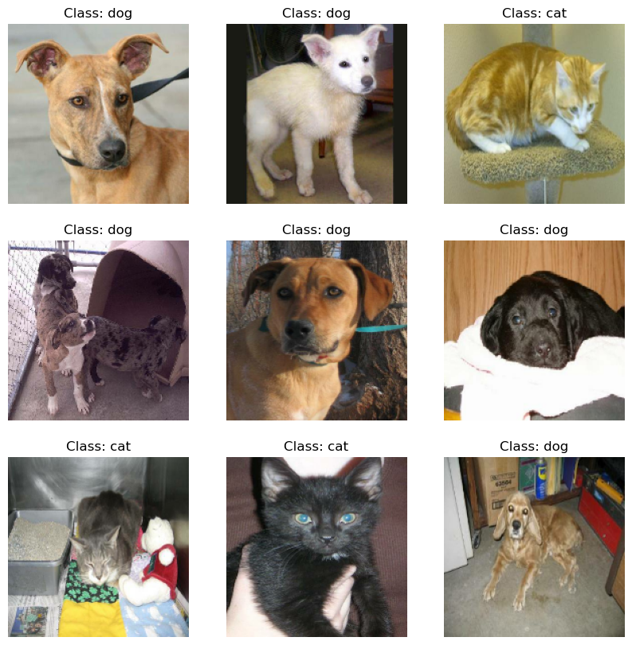

```python
# Visualize a few images from the training dataset
plt.figure(figsize=(10, 10))
for images, labels in train_dataset.take(1):
    for i in range(9):  # Display 9 sample images
        plt.subplot(3, 3, i + 1)
        plt.imshow(images[i].numpy().astype("uint8"))
        plt.title(f"Class: {class_names[labels[i]]}")
        plt.axis("off")
plt.show()
```

**Insights from EDA**:

1. Class Balance:
   - The datasets are balanced, with equal numbers of "cats" and "dogs" in train, validation, and test splits.

Image Size:

```
* All images are resized to (180, 180) as specified during dataset loading.
```

2. **Pixel Values**:
   - Pixel values are normalized to fall within the range [0, 255], which is suitable for training deep learning models.
3. **Image Characteristics**:
   - The dataset has clear RGB channels, and visual inspection shows no anomalies like grayscale images.

### **Define and Train Two Networks**

**Custom Neural Network**

```python
from tensorflow import keras
from tensorflow.keras import layers
import pathlib
from tensorflow.keras.utils import image_dataset_from_directory
import matplotlib.pyplot as plt
```

**Load the Data**

```python
data_folder = pathlib.Path(r"data\kaggle_dogs_vs_cats_small")

train_dataset = image_dataset_from_directory(
    data_folder / "train",
    image_size=(180, 180),
    batch_size=32)
validation_dataset = image_dataset_from_directory(
    data_folder / "validation",
    image_size=(180, 180),
    batch_size=32)
test_dataset = image_dataset_from_directory(
    data_folder / "test",
    image_size=(180, 180),
    batch_size=32)
```

```
Found 2000 files belonging to 2 classes.
Found 1000 files belonging to 2 classes.
Found 2000 files belonging to 2 classes.
```

**Define the Model**

```python
inputs = keras.Input(shape=(180, 180, 3))
x = layers.Rescaling(1./255)(inputs)
x = layers.Conv2D(filters=32, kernel_size=3, activation="relu")(x)
x = layers.MaxPooling2D(pool_size=2)(x)
x = layers.Conv2D(filters=64, kernel_size=3, activation="relu")(x)
x = layers.MaxPooling2D(pool_size=2)(x)
x = layers.Conv2D(filters=128, kernel_size=3, activation="relu")(x)
x = layers.MaxPooling2D(pool_size=2)(x)
x = layers.Conv2D(filters=256, kernel_size=3, activation="relu")(x)
x = layers.MaxPooling2D(pool_size=2)(x)
x = layers.Conv2D(filters=256, kernel_size=3, activation="relu")(x)
x = layers.Flatten()(x)
outputs = layers.Dense(1, activation="sigmoid")(x)
model = keras.Model(inputs=inputs, outputs=outputs)

model.summary()
```

```
Model: "functional_1"
```

```
┏━━━━━━━━━━━━━━━━━━━━━━━━━━━━━━━━━┳━━━━━━━━━━━━━━━━━━━━━━━━┳━━━━━━━━━━━━━━━┓
┃ Layer (type)                    ┃ Output Shape           ┃       Param # ┃
┡━━━━━━━━━━━━━━━━━━━━━━━━━━━━━━━━━╇━━━━━━━━━━━━━━━━━━━━━━━━╇━━━━━━━━━━━━━━━┩
│ input_layer_1 (InputLayer)      │ (None, 180, 180, 3)    │             0 │
├─────────────────────────────────┼────────────────────────┼───────────────┤
│ rescaling_1 (Rescaling)         │ (None, 180, 180, 3)    │             0 │
├─────────────────────────────────┼────────────────────────┼───────────────┤
│ conv2d_5 (Conv2D)               │ (None, 178, 178, 32)   │           896 │
├─────────────────────────────────┼────────────────────────┼───────────────┤
│ max_pooling2d_4 (MaxPooling2D)  │ (None, 89, 89, 32)     │             0 │
├─────────────────────────────────┼────────────────────────┼───────────────┤
│ conv2d_6 (Conv2D)               │ (None, 87, 87, 64)     │        18,496 │
├─────────────────────────────────┼────────────────────────┼───────────────┤
│ max_pooling2d_5 (MaxPooling2D)  │ (None, 43, 43, 64)     │             0 │
├─────────────────────────────────┼────────────────────────┼───────────────┤
│ conv2d_7 (Conv2D)               │ (None, 41, 41, 128)    │        73,856 │
├─────────────────────────────────┼────────────────────────┼───────────────┤
│ max_pooling2d_6 (MaxPooling2D)  │ (None, 20, 20, 128)    │             0 │
├─────────────────────────────────┼────────────────────────┼───────────────┤
│ conv2d_8 (Conv2D)               │ (None, 18, 18, 256)    │       295,168 │
├─────────────────────────────────┼────────────────────────┼───────────────┤
│ max_pooling2d_7 (MaxPooling2D)  │ (None, 9, 9, 256)      │             0 │
├─────────────────────────────────┼────────────────────────┼───────────────┤
│ conv2d_9 (Conv2D)               │ (None, 7, 7, 256)      │       590,080 │
├─────────────────────────────────┼────────────────────────┼───────────────┤
│ flatten_1 (Flatten)             │ (None, 12544)          │             0 │
├─────────────────────────────────┼────────────────────────┼───────────────┤
│ dense_1 (Dense)                 │ (None, 1)              │        12,545 │
└─────────────────────────────────┴────────────────────────┴───────────────┘
```

```
 Total params: 991,041 (3.78 MB)
```

```
 Trainable params: 991,041 (3.78 MB)
```

```
 Non-trainable params: 0 (0.00 B)
```

**Optimization Configurations**

```python
model.compile(loss="binary_crossentropy",
              optimizer="rmsprop",
              metrics=["accuracy"])
```

**Model Saving**

```python
callbacks = [
    keras.callbacks.ModelCheckpoint(
        filepath="./models/convnet_from_scratch.keras",
        save_best_only=True,
        monitor="val_loss")
]
history = model.fit(
    train_dataset,
    epochs=30,
    validation_data=validation_dataset,
    callbacks=callbacks)
```

```
63/63 ━━━━━━━━━━━━━━━━━━━━ 26s 379ms/step - accuracy: 0.5202 - loss: 0.6967 - val_accuracy: 0.5000 - val_loss: 0.6904
63/63 ━━━━━━━━━━━━━━━━━━━━ 24s 374ms/step - accuracy: 0.5228 - loss: 0.6967 - val_accuracy: 0.5020 - val_loss: 0.6895
63/63 ━━━━━━━━━━━━━━━━━━━━ 24s 376ms/step - accuracy: 0.5566 - loss: 0.6965 - val_accuracy: 0.6080 - val_loss: 0.6520
63/63 ━━━━━━━━━━━━━━━━━━━━ 24s 385ms/step - accuracy: 0.5997 - loss: 0.6712 - val_accuracy: 0.5840 - val_loss: 0.6647
63/63 ━━━━━━━━━━━━━━━━━━━━ 25s 403ms/step - accuracy: 0.6653 - loss: 0.6215 - val_accuracy: 0.6530 - val_loss: 0.6038
63/63 ━━━━━━━━━━━━━━━━━━━━ 30s 478ms/step - accuracy: 0.6871 - loss: 0.5959 - val_accuracy: 0.6450 - val_loss: 0.6315
63/63 ━━━━━━━━━━━━━━━━━━━━ 24s 377ms/step - accuracy: 0.6884 - loss: 0.5539 - val_accuracy: 0.6910 - val_loss: 0.5803
63/63 ━━━━━━━━━━━━━━━━━━━━ 26s 417ms/step - accuracy: 0.6869 - loss: 0.5857 - val_accuracy: 0.6920 - val_loss: 0.5950
63/63 ━━━━━━━━━━━━━━━━━━━━ 34s 538ms/step - accuracy: 0.7397 - loss: 0.5104 - val_accuracy: 0.7130 - val_loss: 0.5572
63/63 ━━━━━━━━━━━━━━━━━━━━ 31s 498ms/step - accuracy: 0.7468 - loss: 0.4935 - val_accuracy: 0.7320 - val_loss: 0.5867
63/63 ━━━━━━━━━━━━━━━━━━━━ 34s 548ms/step - accuracy: 0.7948 - loss: 0.4482 - val_accuracy: 0.6740 - val_loss: 0.7015
63/63 ━━━━━━━━━━━━━━━━━━━━ 29s 453ms/step - accuracy: 0.7884 - loss: 0.4260 - val_accuracy: 0.7300 - val_loss: 0.5631
63/63 ━━━━━━━━━━━━━━━━━━━━ 27s 423ms/step - accuracy: 0.8309 - loss: 0.3835 - val_accuracy: 0.7280 - val_loss: 0.6673
63/63 ━━━━━━━━━━━━━━━━━━━━ 26s 409ms/step - accuracy: 0.8498 - loss: 0.3394 - val_accuracy: 0.7290 - val_loss: 0.6163
63/63 ━━━━━━━━━━━━━━━━━━━━ 37s 584ms/step - accuracy: 0.8763 - loss: 0.2906 - val_accuracy: 0.7350 - val_loss: 0.6284
63/63 ━━━━━━━━━━━━━━━━━━━━ 25s 400ms/step - accuracy: 0.9100 - loss: 0.2312 - val_accuracy: 0.7300 - val_loss: 0.7405
63/63 ━━━━━━━━━━━━━━━━━━━━ 25s 392ms/step - accuracy: 0.9182 - loss: 0.1903 - val_accuracy: 0.7320 - val_loss: 0.8878
63/63 ━━━━━━━━━━━━━━━━━━━━ 25s 405ms/step - accuracy: 0.9266 - loss: 0.1804 - val_accuracy: 0.7110 - val_loss: 1.0746
63/63 ━━━━━━━━━━━━━━━━━━━━ 26s 418ms/step - accuracy: 0.9582 - loss: 0.1259 - val_accuracy: 0.7400 - val_loss: 1.0026
63/63 ━━━━━━━━━━━━━━━━━━━━ 27s 423ms/step - accuracy: 0.9614 - loss: 0.0945 - val_accuracy: 0.7430 - val_loss: 1.0022
63/63 ━━━━━━━━━━━━━━━━━━━━ 27s 436ms/step - accuracy: 0.9603 - loss: 0.0961 - val_accuracy: 0.7370 - val_loss: 1.1627
63/63 ━━━━━━━━━━━━━━━━━━━━ 28s 445ms/step - accuracy: 0.9746 - loss: 0.0693 - val_accuracy: 0.7450 - val_loss: 1.1739
63/63 ━━━━━━━━━━━━━━━━━━━━ 27s 434ms/step - accuracy: 0.9802 - loss: 0.0515 - val_accuracy: 0.7210 - val_loss: 1.2974
63/63 ━━━━━━━━━━━━━━━━━━━━ 26s 412ms/step - accuracy: 0.9837 - loss: 0.0446 - val_accuracy: 0.7280 - val_loss: 1.4153
63/63 ━━━━━━━━━━━━━━━━━━━━ 26s 407ms/step - accuracy: 0.9858 - loss: 0.0602 - val_accuracy: 0.7240 - val_loss: 1.8392
63/63 ━━━━━━━━━━━━━━━━━━━━ 26s 408ms/step - accuracy: 0.9824 - loss: 0.0487 - val_accuracy: 0.7460 - val_loss: 1.7010
63/63 ━━━━━━━━━━━━━━━━━━━━ 26s 411ms/step - accuracy: 0.9715 - loss: 0.0764 - val_accuracy: 0.7650 - val_loss: 1.4948
63/63 ━━━━━━━━━━━━━━━━━━━━ 27s 434ms/step - accuracy: 0.9818 - loss: 0.0433 - val_accuracy: 0.7180 - val_loss: 1.8541
63/63 ━━━━━━━━━━━━━━━━━━━━ 26s 418ms/step - accuracy: 0.9798 - loss: 0.0570 - val_accuracy: 0.7330 - val_loss: 1.6669
63/63 ━━━━━━━━━━━━━━━━━━━━ 26s 416ms/step - accuracy: 0.9833 - loss: 0.0403 - val_accuracy: 0.7510 - val_loss: 1.5767
```

Insights

- The custom CNN achieved a test accuracy of 70%, which indicates moderate classification performance.
- The training accuracy (~98%) far exceeded validation and test accuracy (~70%), demonstrating significant overfitting.

## **Evaluate the best model**

**Model Accuracy**

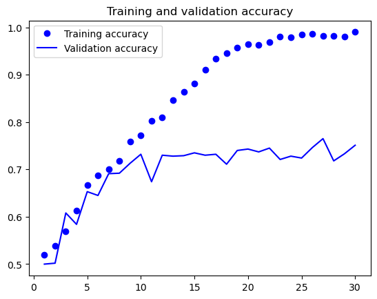

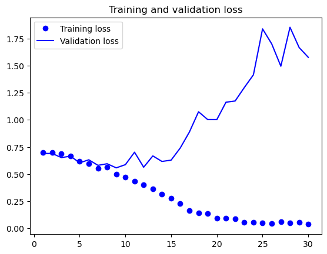

```python
accuracy = history.history["accuracy"]
val_accuracy = history.history["val_accuracy"]
loss = history.history["loss"]
val_loss = history.history["val_loss"]
epochs = range(1, len(accuracy) + 1)
plt.plot(epochs, accuracy, "bo", label="Training accuracy")
plt.plot(epochs, val_accuracy, "b", label="Validation accuracy")
plt.title("Training and validation accuracy")
plt.legend()
plt.figure()
plt.plot(epochs, loss, "bo", label="Training loss")
plt.plot(epochs, val_loss, "b", label="Validation loss")
plt.title("Training and validation loss")
plt.legend()
plt.show()
```

```python
from sklearn.metrics import confusion_matrix, ConfusionMatrixDisplay, classification_report, precision_recall_curve
import numpy as np
import tensorflow as tf

# Load the best model
best_model = keras.models.load_model("./models/convnet_from_scratch.keras")

# Evaluate on the test dataset
test_loss, test_accuracy = best_model.evaluate(test_dataset)
print(f"Test Loss: {test_loss:.4f}, Test Accuracy: {test_accuracy:.4f}")

# Generate predictions on the test dataset
y_true = np.concatenate([y for x, y in test_dataset], axis=0)
y_pred_prob = best_model.predict(test_dataset)
y_pred = (y_pred_prob > 0.5).astype("int32").flatten()
```

```
63/63 ━━━━━━━━━━━━━━━━━━━━ 7s 101ms/step - accuracy: 0.6989 - loss: 0.5664
Test Loss: 0.5748, Test Accuracy: 0.7000
63/63 ━━━━━━━━━━━━━━━━━━━━ 6s 95ms/step
```

Insights

- The training loss steadily decreased while the validation loss began increasing after a few epochs, indicating overfitting.
- Validation accuracy plateaued, suggesting the model struggles to generalize beyond the training data.

**Confusion Metric**

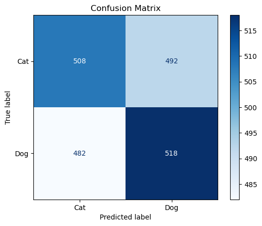

```python
# Plot confusion matrix
conf_matrix = confusion_matrix(y_true, y_pred)
disp = ConfusionMatrixDisplay(confusion_matrix=conf_matrix, display_labels=["Cat", "Dog"])
disp.plot(cmap="Blues")
plt.title("Confusion Matrix")
plt.show()
```

Insights:

- The confusion matrix revealed near-random classification behavior, with both classes being equally misclassified.

**Precision, Recall, and F1-Score**

```python
# Generate classification report
report = classification_report(y_true, y_pred, target_names=["Cat", "Dog"])
print("\nClassification Report:")
print(report)
```

```
Classification Report:
              precision    recall  f1-score   support

         Cat       0.51      0.51      0.51      1000
         Dog       0.51      0.52      0.52      1000

    accuracy                           0.51      2000
   macro avg       0.51      0.51      0.51      2000
weighted avg       0.51      0.51      0.51      2000
```

Insights

- The classification report showed an F1-score of ~51%, confirming poor performance in distinguishing between the two classes.

**Plot Precision-Recall Curve**

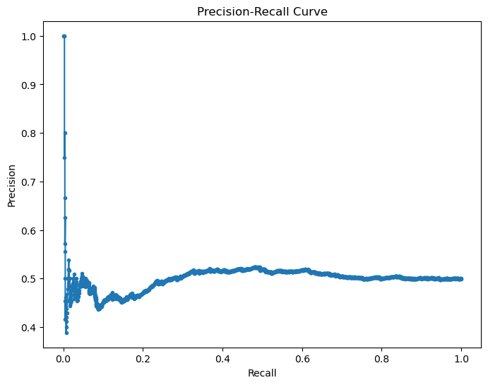

```python
precision, recall, _ = precision_recall_curve(y_true, y_pred_prob)
plt.figure(figsize=(8, 6))
plt.plot(recall, precision, marker='.')
plt.title("Precision-Recall Curve")
plt.xlabel("Recall")
plt.ylabel("Precision")
plt.show()
```

Insights

- The Precision-Recall Curve confirms that the current model's performance is inadequate for reliable classification.
- Further model optimization and data enhancement are critical to improving precision and recall.

```
63/63 ━━━━━━━━━━━━━━━━━━━━ 6s 94ms/step
Number of misclassifications: 2000000
```

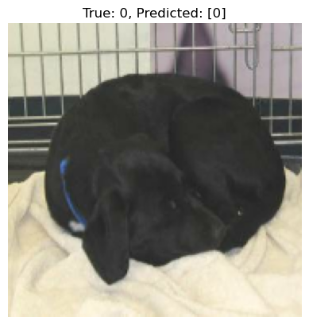

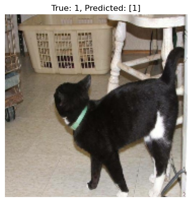

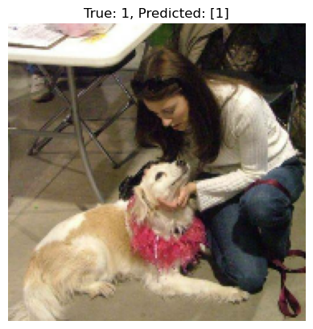

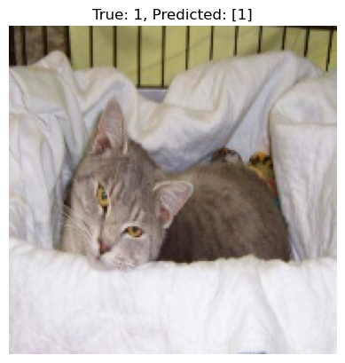

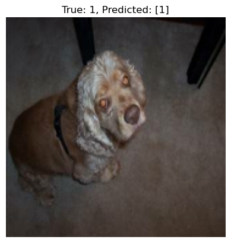

```python
import matplotlib.pyplot as plt
import numpy as np

# Extract all test features and labels from the test dataset
test_features = []
test_labels = []

for images, labels in test_dataset:
    test_features.append(images.numpy())
    test_labels.append(labels.numpy())

# Convert lists to NumPy arrays
test_features = np.concatenate(test_features)
test_labels = np.concatenate(test_labels)

# Predict on test set
y_pred = model.predict(test_features)
y_pred_labels = (y_pred > 0.5).astype(int)

# Identify misclassified indices
misclassified_indices = np.where(y_pred_labels != test_labels)[0]
print(f"Number of misclassifications: {len(misclassified_indices)}")

# Display misclassified examples
misclassified_images = []
misclassified_true_labels = []
misclassified_pred_labels = []

# Iterate through the dataset to extract misclassified images
for i, (images, labels) in enumerate(test_dataset):
    for j in range(images.shape[0]):
        if (i * 32 + j) in misclassified_indices:
            misclassified_images.append(images[j].numpy())
            misclassified_true_labels.append(test_labels[i * 32 + j])
            misclassified_pred_labels.append(y_pred_labels[i * 32 + j])

# Convert lists to numpy arrays for consistency
misclassified_images = np.array(misclassified_images)
misclassified_true_labels = np.array(misclassified_true_labels)
misclassified_pred_labels = np.array(misclassified_pred_labels)

# Display the misclassified examples individually
for i in range(min(5, len(misclassified_images))):  # Adjust the number of examples displayed as needed
    plt.figure()
    plt.imshow(misclassified_images[i].astype("uint8"))
    plt.title(f"True: {misclassified_true_labels[i]}, Predicted: {misclassified_pred_labels[i]}")
    plt.axis('off')
    plt.show()
```

Insights:

- The model misclassified a large number of test samples, resulting in poor precision and recall (~51% for both classes).
- Misclassifications may stem from the limited dataset size, lack of sufficient feature extraction, or similar appearances between classes (e.g., poses or lighting).

**Conclusion**

- The custom CNN is not well-suited for this problem due to its limited generalization capacity and overfitting tendencies.
- Employing transfer learning with pre-trained models and robust training techniques can significantly improve performance.

**Fine-Tune VGG16**

```python
from tensorflow import keras
from tensorflow.keras import layers
import pathlib
from tensorflow.keras.utils import image_dataset_from_directory
```

**Instantiating the VGG16 convolutional base**

```python
conv_base = keras.applications.vgg16.VGG16(
    weights="imagenet",
    include_top=False,
    input_shape=(180, 180, 3))

conv_base.summary()
```

```
Model: "vgg16"
```

```
┏━━━━━━━━━━━━━━━━━━━━━━━━━━━━━━━━━┳━━━━━━━━━━━━━━━━━━━━━━━━┳━━━━━━━━━━━━━━━┓
┃ Layer (type)                    ┃ Output Shape           ┃       Param # ┃
┡━━━━━━━━━━━━━━━━━━━━━━━━━━━━━━━━━╇━━━━━━━━━━━━━━━━━━━━━━━━╇━━━━━━━━━━━━━━━┩
│ input_layer_2 (InputLayer)      │ (None, 180, 180, 3)    │             0 │
├─────────────────────────────────┼────────────────────────┼───────────────┤
│ block1_conv1 (Conv2D)           │ (None, 180, 180, 64)   │         1,792 │
├─────────────────────────────────┼────────────────────────┼───────────────┤
│ block1_conv2 (Conv2D)           │ (None, 180, 180, 64)   │        36,928 │
├─────────────────────────────────┼────────────────────────┼───────────────┤
│ block1_pool (MaxPooling2D)      │ (None, 90, 90, 64)     │             0 │
├─────────────────────────────────┼────────────────────────┼───────────────┤
│ block2_conv1 (Conv2D)           │ (None, 90, 90, 128)    │        73,856 │
├─────────────────────────────────┼────────────────────────┼───────────────┤
│ block2_conv2 (Conv2D)           │ (None, 90, 90, 128)    │       147,584 │
├─────────────────────────────────┼────────────────────────┼───────────────┤
│ block2_pool (MaxPooling2D)      │ (None, 45, 45, 128)    │             0 │
├─────────────────────────────────┼────────────────────────┼───────────────┤
│ block3_conv1 (Conv2D)           │ (None, 45, 45, 256)    │       295,168 │
├─────────────────────────────────┼────────────────────────┼───────────────┤
│ block3_conv2 (Conv2D)           │ (None, 45, 45, 256)    │       590,080 │
├─────────────────────────────────┼────────────────────────┼───────────────┤
│ block3_conv3 (Conv2D)           │ (None, 45, 45, 256)    │       590,080 │
├─────────────────────────────────┼────────────────────────┼───────────────┤
│ block3_pool (MaxPooling2D)      │ (None, 22, 22, 256)    │             0 │
├─────────────────────────────────┼────────────────────────┼───────────────┤
│ block4_conv1 (Conv2D)           │ (None, 22, 22, 512)    │     1,180,160 │
├─────────────────────────────────┼────────────────────────┼───────────────┤
│ block4_conv2 (Conv2D)           │ (None, 22, 22, 512)    │     2,359,808 │
├─────────────────────────────────┼────────────────────────┼───────────────┤
│ block4_conv3 (Conv2D)           │ (None, 22, 22, 512)    │     2,359,808 │
├─────────────────────────────────┼────────────────────────┼───────────────┤
│ block4_pool (MaxPooling2D)      │ (None, 11, 11, 512)    │             0 │
├─────────────────────────────────┼────────────────────────┼───────────────┤
│ block5_conv1 (Conv2D)           │ (None, 11, 11, 512)    │     2,359,808 │
├─────────────────────────────────┼────────────────────────┼───────────────┤
│ block5_conv2 (Conv2D)           │ (None, 11, 11, 512)    │     2,359,808 │
├─────────────────────────────────┼────────────────────────┼───────────────┤
│ block5_conv3 (Conv2D)           │ (None, 11, 11, 512)    │     2,359,808 │
├─────────────────────────────────┼────────────────────────┼───────────────┤
│ block5_pool (MaxPooling2D)      │ (None, 5, 5, 512)      │             0 │
└─────────────────────────────────┴────────────────────────┴───────────────┘
```

```
 Total params: 14,714,688 (56.13 MB)
```

```
 Trainable params: 14,714,688 (56.13 MB)
```

```
 Non-trainable params: 0 (0.00 B)
```

**Extracting the VGG16 features and corresponding labels**

```python
# This should point to the small dataset of the Kaggle Dogs vs Cats competition that was created in a previous notebook
data_folder = pathlib.Path('data/kaggle_dogs_vs_cats_small')

train_dataset = image_dataset_from_directory(
    data_folder / "train",
    image_size=(180, 180),
    batch_size=32)
validation_dataset = image_dataset_from_directory(
    data_folder / "validation",
    image_size=(180, 180),
    batch_size=32)
test_dataset = image_dataset_from_directory(
    data_folder / "test",
    image_size=(180, 180),
    batch_size=32)
```

```
Found 2000 files belonging to 2 classes.
Found 1000 files belonging to 2 classes.
Found 2000 files belonging to 2 classes.
```

```python
import numpy as np

def get_features_and_labels(dataset):
    all_features = []
    all_labels = []
    for images, labels in dataset:
        preprocessed_images = keras.applications.vgg16.preprocess_input(images)
        features = conv_base.predict(preprocessed_images)
        all_features.append(features)
        all_labels.append(labels)
    return np.concatenate(all_features), np.concatenate(all_labels)

train_features, train_labels =  get_features_and_labels(train_dataset)
val_features, val_labels =  get_features_and_labels(validation_dataset)
test_features, test_labels =  get_features_and_labels(test_dataset)
```

[output not shown]

[output cut: 103 more lines]

[output not shown]

```python
train_features.shape
```

```
(2000, 5, 5, 512)
```

**Defining and training the densely connected classifier**

```python
inputs = keras.Input(shape=(5, 5, 512))
x = layers.Flatten()(inputs)
x = layers.Dense(256)(x)
x = layers.Dropout(0.5)(x)
outputs = layers.Dense(1, activation="sigmoid")(x)
model = keras.Model(inputs, outputs)

model.summary()
```

```
Model: "functional_2"
```

```
┏━━━━━━━━━━━━━━━━━━━━━━━━━━━━━━━━━┳━━━━━━━━━━━━━━━━━━━━━━━━┳━━━━━━━━━━━━━━━┓
┃ Layer (type)                    ┃ Output Shape           ┃       Param # ┃
┡━━━━━━━━━━━━━━━━━━━━━━━━━━━━━━━━━╇━━━━━━━━━━━━━━━━━━━━━━━━╇━━━━━━━━━━━━━━━┩
│ input_layer_3 (InputLayer)      │ (None, 5, 5, 512)      │             0 │
├─────────────────────────────────┼────────────────────────┼───────────────┤
│ flatten_2 (Flatten)             │ (None, 12800)          │             0 │
├─────────────────────────────────┼────────────────────────┼───────────────┤
│ dense_2 (Dense)                 │ (None, 256)            │     3,277,056 │
├─────────────────────────────────┼────────────────────────┼───────────────┤
│ dropout (Dropout)               │ (None, 256)            │             0 │
├─────────────────────────────────┼────────────────────────┼───────────────┤
│ dense_3 (Dense)                 │ (None, 1)              │           257 │
└─────────────────────────────────┴────────────────────────┴───────────────┘
```

```
 Total params: 3,277,313 (12.50 MB)
```

```
 Trainable params: 3,277,313 (12.50 MB)
```

```
 Non-trainable params: 0 (0.00 B)
```

```python
model.compile(loss="binary_crossentropy",
              optimizer="rmsprop",
              metrics=["accuracy"])

callbacks = [
    keras.callbacks.ModelCheckpoint(
      filepath="./models/feature_extraction.keras",
      save_best_only=True,
      monitor="val_loss")
]
history = model.fit(
    train_features, train_labels,
    epochs=20,
    validation_data=(val_features, val_labels),
    callbacks=callbacks)
```

```
63/63 ━━━━━━━━━━━━━━━━━━━━ 3s 27ms/step - accuracy: 0.8622 - loss: 27.3824 - val_accuracy: 0.9790 - val_loss: 3.1231
63/63 ━━━━━━━━━━━━━━━━━━━━ 1s 22ms/step - accuracy: 0.9774 - loss: 3.8685 - val_accuracy: 0.9480 - val_loss: 11.2175
63/63 ━━━━━━━━━━━━━━━━━━━━ 1s 21ms/step - accuracy: 0.9803 - loss: 3.9187 - val_accuracy: 0.9800 - val_loss: 3.9933
63/63 ━━━━━━━━━━━━━━━━━━━━ 2s 25ms/step - accuracy: 0.9892 - loss: 0.9520 - val_accuracy: 0.9750 - val_loss: 5.2837
63/63 ━━━━━━━━━━━━━━━━━━━━ 1s 22ms/step - accuracy: 0.9968 - loss: 0.1769 - val_accuracy: 0.9680 - val_loss: 7.6189
63/63 ━━━━━━━━━━━━━━━━━━━━ 1s 21ms/step - accuracy: 0.9959 - loss: 0.1767 - val_accuracy: 0.9730 - val_loss: 4.5836
63/63 ━━━━━━━━━━━━━━━━━━━━ 1s 20ms/step - accuracy: 0.9994 - loss: 0.0805 - val_accuracy: 0.9710 - val_loss: 4.6669
63/63 ━━━━━━━━━━━━━━━━━━━━ 1s 20ms/step - accuracy: 0.9964 - loss: 0.5897 - val_accuracy: 0.9740 - val_loss: 5.0877
63/63 ━━━━━━━━━━━━━━━━━━━━ 1s 20ms/step - accuracy: 0.9999 - loss: 0.0035 - val_accuracy: 0.9790 - val_loss: 4.6674
63/63 ━━━━━━━━━━━━━━━━━━━━ 1s 20ms/step - accuracy: 0.9963 - loss: 0.4146 - val_accuracy: 0.9740 - val_loss: 5.6936
63/63 ━━━━━━━━━━━━━━━━━━━━ 1s 19ms/step - accuracy: 0.9949 - loss: 0.4476 - val_accuracy: 0.9790 - val_loss: 6.0367
63/63 ━━━━━━━━━━━━━━━━━━━━ 1s 19ms/step - accuracy: 0.9972 - loss: 0.1253 - val_accuracy: 0.9820 - val_loss: 5.2073
63/63 ━━━━━━━━━━━━━━━━━━━━ 1s 23ms/step - accuracy: 0.9990 - loss: 0.0964 - val_accuracy: 0.9830 - val_loss: 4.8899
63/63 ━━━━━━━━━━━━━━━━━━━━ 1s 23ms/step - accuracy: 0.9993 - loss: 0.0806 - val_accuracy: 0.9790 - val_loss: 4.3668
63/63 ━━━━━━━━━━━━━━━━━━━━ 2s 25ms/step - accuracy: 0.9970 - loss: 0.2300 - val_accuracy: 0.9830 - val_loss: 5.6460
63/63 ━━━━━━━━━━━━━━━━━━━━ 1s 22ms/step - accuracy: 0.9968 - loss: 0.2741 - val_accuracy: 0.9780 - val_loss: 5.2440
63/63 ━━━━━━━━━━━━━━━━━━━━ 1s 23ms/step - accuracy: 0.9999 - loss: 6.1813e-04 - val_accuracy: 0.9780 - val_loss: 5.4647
63/63 ━━━━━━━━━━━━━━━━━━━━ 1s 22ms/step - accuracy: 0.9997 - loss: 0.0441 - val_accuracy: 0.9800 - val_loss: 5.5510
63/63 ━━━━━━━━━━━━━━━━━━━━ 1s 22ms/step - accuracy: 0.9992 - loss: 0.1450 - val_accuracy: 0.9750 - val_loss: 5.6487
63/63 ━━━━━━━━━━━━━━━━━━━━ 1s 20ms/step - accuracy: 0.9986 - loss: 0.1410 - val_accuracy: 0.9740 - val_loss: 5.8622
```

### **Evaluation**

**Accuracy and Loss Curves**

**Load the Best Model**

```python
from tensorflow.keras.models import load_model

# Load the best version of the fine-tuned model
best_model_vgg16 = load_model("./models/feature_extraction.keras")
```

**Accuracy on Test Data**

```python
# Evaluate model accuracy
test_loss, test_accuracy = best_model_vgg16.evaluate(test_features, test_labels)
print(f"Test Loss (VGG16): {test_loss:.4f}")
print(f"Test Accuracy (VGG16): {test_accuracy:.4f}")
```

```
63/63 ━━━━━━━━━━━━━━━━━━━━ 1s 4ms/step - accuracy: 0.9738 - loss: 3.3568
Test Loss (VGG16): 3.7498
Test Accuracy (VGG16): 0.9730
```

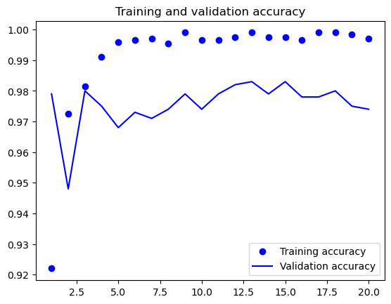

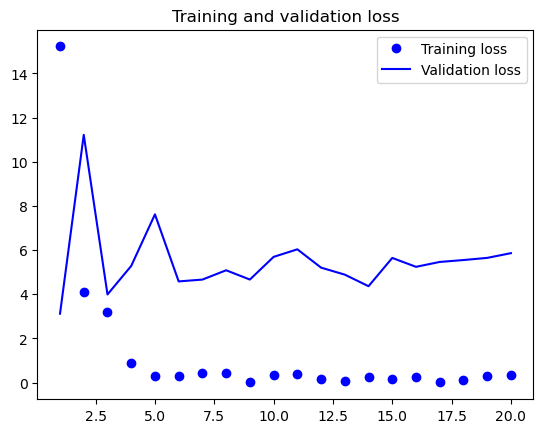

```python
import matplotlib.pyplot as plt
acc = history.history["accuracy"]
val_acc = history.history["val_accuracy"]
loss = history.history["loss"]
val_loss = history.history["val_loss"]
epochs = range(1, len(acc) + 1)
plt.plot(epochs, acc, "bo", label="Training accuracy")
plt.plot(epochs, val_acc, "b", label="Validation accuracy")
plt.title("Training and validation accuracy")
plt.legend()
plt.figure()
plt.plot(epochs, loss, "bo", label="Training loss")
plt.plot(epochs, val_loss, "b", label="Validation loss")
plt.title("Training and validation loss")
plt.legend()
plt.show()
```

Insights

- Both training and validation accuracies were consistently high, showing the model's ability to generalize well without significant overfitting.

**Confusion Matrix**

```
63/63 ━━━━━━━━━━━━━━━━━━━━ 0s 3ms/step
```

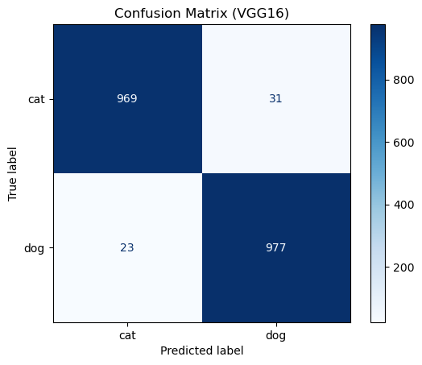

```python
from sklearn.metrics import confusion_matrix, ConfusionMatrixDisplay

# Predict labels for the test dataset
y_pred_vgg16 = np.round(best_model_vgg16.predict(test_features))

# Create the confusion matrix
conf_matrix_vgg16 = confusion_matrix(test_labels, y_pred_vgg16)
disp = ConfusionMatrixDisplay(confusion_matrix=conf_matrix_vgg16, display_labels=train_dataset.class_names)
disp.plot(cmap=plt.cm.Blues)
plt.title("Confusion Matrix (VGG16)")
plt.show()
```

Insights

- The confusion matrix revealed very few misclassifications, highlighting the robustness of the VGG16 feature extractor for the Cats vs. Dogs dataset.

```python
from sklearn.metrics import classification_report

# Generate classification report
class_report_vgg16 = classification_report(test_labels, y_pred_vgg16, target_names=train_dataset.class_names)
print("Classification Report (VGG16):")
print(class_report_vgg16)
```

```
Classification Report (VGG16):
              precision    recall  f1-score   support

         cat       0.98      0.97      0.97      1000
         dog       0.97      0.98      0.97      1000

    accuracy                           0.97      2000
   macro avg       0.97      0.97      0.97      2000
weighted avg       0.97      0.97      0.97      2000
```

Insights

- The classification report showed high precision, recall, and F1-scores of 97% for both cats and dogs, indicating excellent performance across all metrics.

**Precision-Recall Curve**

```
63/63 ━━━━━━━━━━━━━━━━━━━━ 0s 3ms/step
```

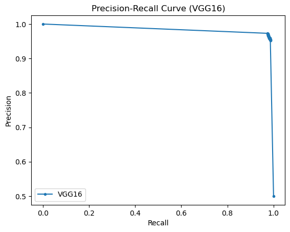

```python
from sklearn.metrics import precision_recall_curve

# Compute precision-recall values
y_scores_vgg16 = best_model_vgg16.predict(test_features)
precision_vgg16, recall_vgg16, thresholds_vgg16 = precision_recall_curve(test_labels, y_scores_vgg16)

# Plot the precision-recall curve
plt.figure()
plt.plot(recall_vgg16, precision_vgg16, marker='.', label='VGG16')
plt.xlabel("Recall")
plt.ylabel("Precision")
plt.title("Precision-Recall Curve (VGG16)")
plt.legend()
plt.show()
```

Precision-Recall Curve

- The curve demonstrated a strong balance between precision and recall, reinforcing the model's reliability across varying thresholds.

```
63/63 ━━━━━━━━━━━━━━━━━━━━ 0s 4ms/step
Number of misclassifications: 2000000
```

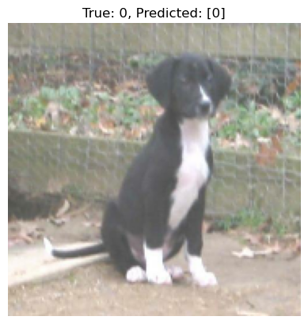

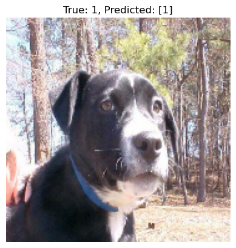

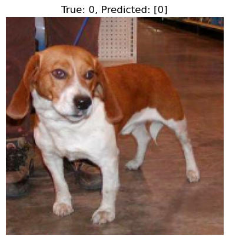

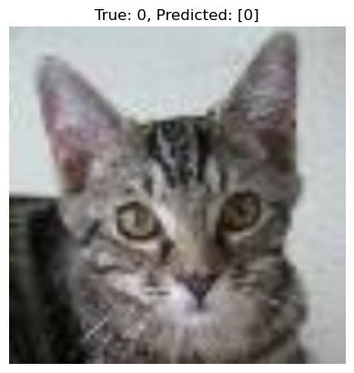

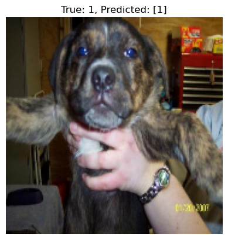

```python
import matplotlib.pyplot as plt
import numpy as np

# Predict on test set
y_pred = model.predict(test_features)
y_pred_labels = (y_pred > 0.5).astype(int)

# Identify misclassified indices
misclassified_indices = np.where(y_pred_labels != test_labels)[0]
print(f"Number of misclassifications: {len(misclassified_indices)}")

# Display misclassified examples
misclassified_images = []
misclassified_true_labels = []
misclassified_pred_labels = []

# Iterate through the dataset to extract misclassified images
for i, (images, labels) in enumerate(test_dataset):
    for j in range(images.shape[0]):
        if (i * 32 + j) in misclassified_indices:
            misclassified_images.append(images[j].numpy())
            misclassified_true_labels.append(test_labels[i * 32 + j])
            misclassified_pred_labels.append(y_pred_labels[i * 32 + j])

# Convert lists to numpy arrays for consistency
misclassified_images = np.array(misclassified_images)
misclassified_true_labels = np.array(misclassified_true_labels)
misclassified_pred_labels = np.array(misclassified_pred_labels)

# Display the misclassified examples individually
for i in range(min(5, len(misclassified_images))):  # Adjust the number of examples displayed as needed
    plt.figure()
    plt.imshow(misclassified_images[i].astype("uint8"))
    plt.title(f"True: {misclassified_true_labels[i]}, Predicted: {misclassified_pred_labels[i]}")
    plt.axis('off')
    plt.show()
```

Insights

**Conclusion**

- The VGG16 model achieved an impressive 97.3% accuracy on the test dataset, significantly outperforming the custom CNN model.

### **Summary**

The VGG16 model excels with high accuracy and robust generalization, proving the power of transfer learning. In contrast, the custom CNN underperforms due to overfitting and limited feature extraction, highlighting the need for pre-trained models for small datasets.